### Definición de grafo

Un **grafo simple** consiste en un set finito y no vacio denominado V(G) de elementos llamados **vertices o nodos** y, un set finito E(G) de **aristas** que unen los pares no ordenados de V(G).

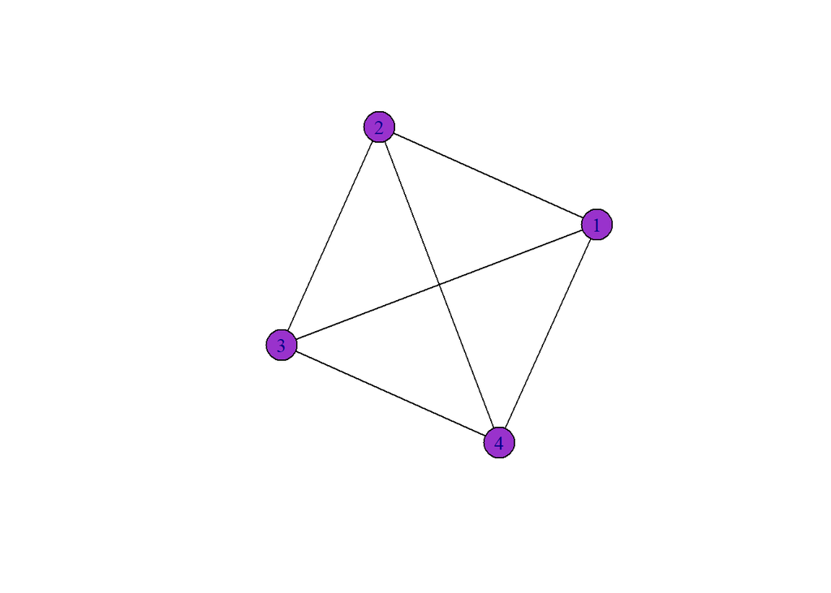

```r
#Importar librerias
library(igraph)         # Biblioteca para análisis de redes.
library(tidyverse)      # Colección de bibliotecas para manipulación de datos.
library(viridis)        # Biblioteca con paletas de colores.
# Generamos una red aleatoria de 4 nodos no dirigida.
# Para poder reproducirla, dado que tiene componentes aleatorios,
# Fijamos la semilla del generador de números pseudoaleatorios.
set.seed(22051996)
g <- sample_gnp(4, 1, directed = FALSE, loops = FALSE)
plot(g,
     vertex.color="darkorchid",  # color de los nodos
     vertex.size=20,             # tamaño de los nodos
     edge.color="black")         # color de las aristas
```

Calcularemos el set de vertices **V(G)** y el set de aristas **V(E)** del grafo generado arriba, el cual sería considerado un **grafo simple**, en el cual por lo menos una arista esta uniendo un dado par de vertices.

```r
V(g) #Calcular nodos
```

```
## + 4/4 vertices, from e5a19ed:
## [1] 1 2 3 4
```

```r
E(g) #Calcular aristas
```

```
## + 6/6 edges from e5a19ed:
## [1] 1--2 1--3 1--4 2--3 2--4 3--4
```

A continuación se presentara un **grafo general** o simplemente un **grafo**, dicho objeto permite la presencia de loops y aristas multiples. Un **loop** es aquella arista que conecta un nodo con si mismo. Las **aristas multiples** son aquellas aristas que conectan dos vertices distintos más de una vez.

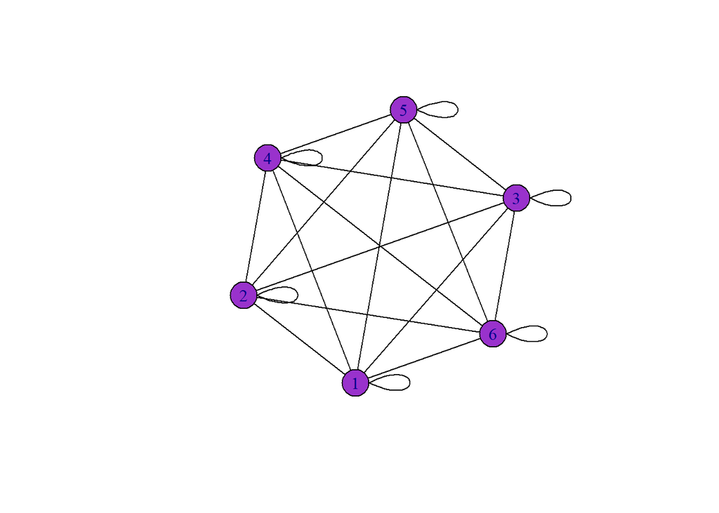

```r
set.seed(22051996)
g <- sample_gnp(6, 1, directed = FALSE, loops = TRUE) #Crea un grafo aleatorio con 6 nodos, no dirigido y con loops
plot(g,
     vertex.color="darkorchid",  # color de los nodos
     vertex.size=20,             # tamaño de los nodos
     edge.color="black")         # color de las aristas
```

```r
V(g) #Calcular nodos
```

```
## + 6/6 vertices, from e5bd747:
## [1] 1 2 3 4 5 6
```

```r
E(g) #Calcular aristas
```

```
## + 21/21 edges from e5bd747:
##  [1] 1--1 1--2 1--3 1--4 1--5 1--6 2--2 2--3 2--4 2--5 2--6 3--3 3--4 3--5 3--6
## [16] 4--4 4--5 4--6 5--5 5--6 6--6
```

En el grafo creado todos los nodos tienen un loop,ninguna de las aristas es multiple. ###Isomorfismo Se dice que entre dos grafos G1 y G2 cuyos nodos no estan etiquetados existe isomorfía si al etiquetarlos cada una de los nodos se corresponde a la perfección con el grafo de referencia. Así el grafo recien creado es isomorfo con el anterior.

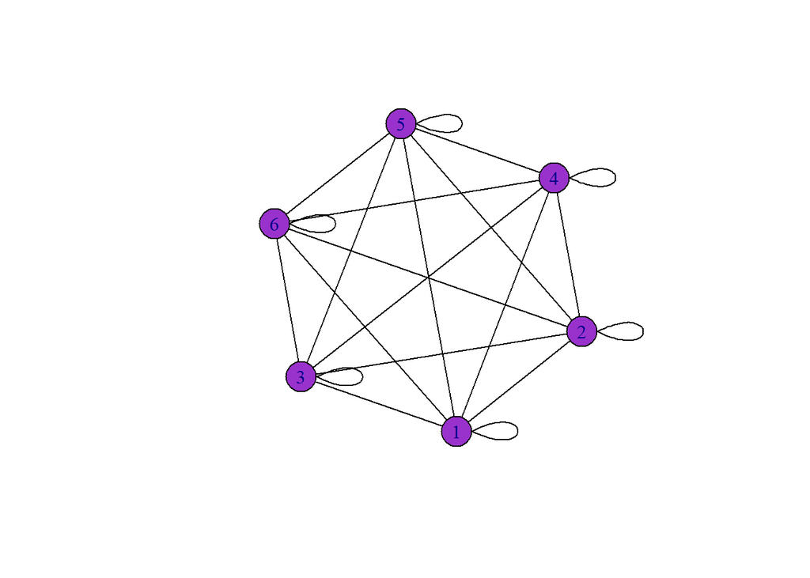

```r
set.seed(22051998)
g <- sample_gnp(6, 1, directed = FALSE, loops = TRUE) #Crea un grafo aleatorio con 6 nodos, no dirigido y con loops
plot(g,
     vertex.color="darkorchid",  # color de los nodos
     vertex.size=20,             # tamaño de los nodos
     edge.color="black")         # color de las aristas
```

```r
V(g) #Calcular nodos
```

```
## + 6/6 vertices, from e5cb13d:
## [1] 1 2 3 4 5 6
```

```r
E(g) #Calcular aristas
```

```
## + 21/21 edges from e5cb13d:
##  [1] 1--1 1--2 1--3 1--4 1--5 1--6 2--2 2--3 2--4 2--5 2--6 3--3 3--4 3--5 3--6
## [16] 4--4 4--5 4--6 5--5 5--6 6--6
```

###Conectividad Se dice que un grafo es **conectado** si no puede ser expresado como la unión de dos grafos (G= G1 U G2) . Así, todo grafo que pueda ser expresado de esa forma Es un grafo **desconectado**

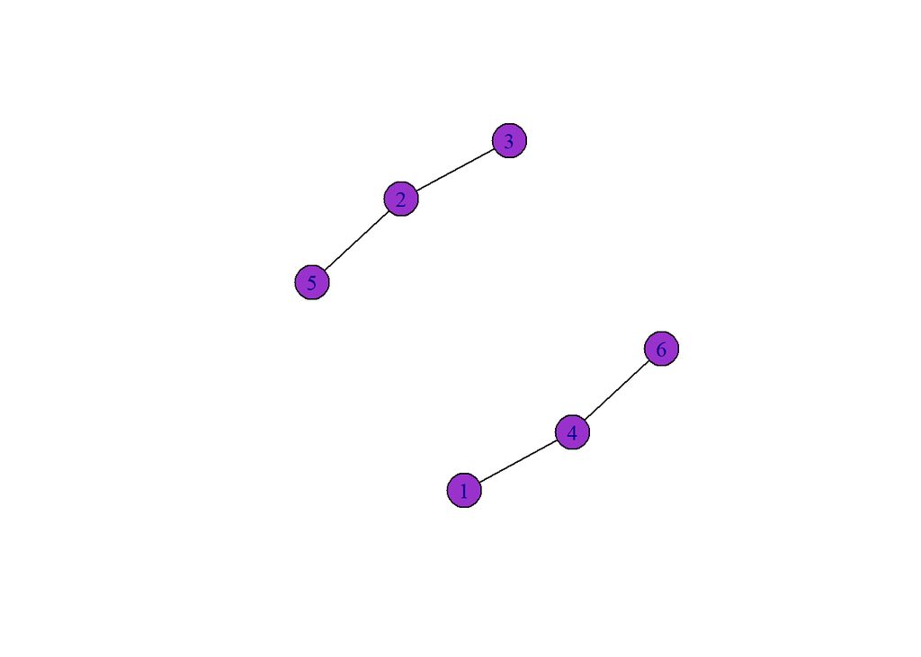

```r
set.seed(22051996)
g <- sample_gnp(6, 0.3, directed = FALSE, loops = FALSE) #Crea un grafo aleatorio con 6 nodos, no dirigido y con loops
plot(g,
     vertex.color="darkorchid",  # color de los nodos
     vertex.size=20,             # tamaño de los nodos
     edge.color="black")         # color de las aristas
```

###Proximidad Decimos que dos vertices llamense v y w de un Grafo G son **incidentes** si hay una arista vw uniendolos.Así, en el ejemplo arriba, la arista que une el nodo 4 es incidente con el 1 y, las aritas que unen 1 y 6 son incidentes con el nodo 4. Del mismo modo en el componente restante, las aristas que unen los vertices 5 y 3 son incidentes del vertice 2. Por otro lado, se dice que las aristas que comporten un nodo son **adyacentes**, así, la arista 5,2 es adyacente de la arista 2,3. Mientras que en el otro componente la arista 1,4 es adyacente de la arista 4,6.

Cuando hablamos del concepto de **grado** de un nodo v de G, este es el número de aristas incidentes con v y se denota deg(v)

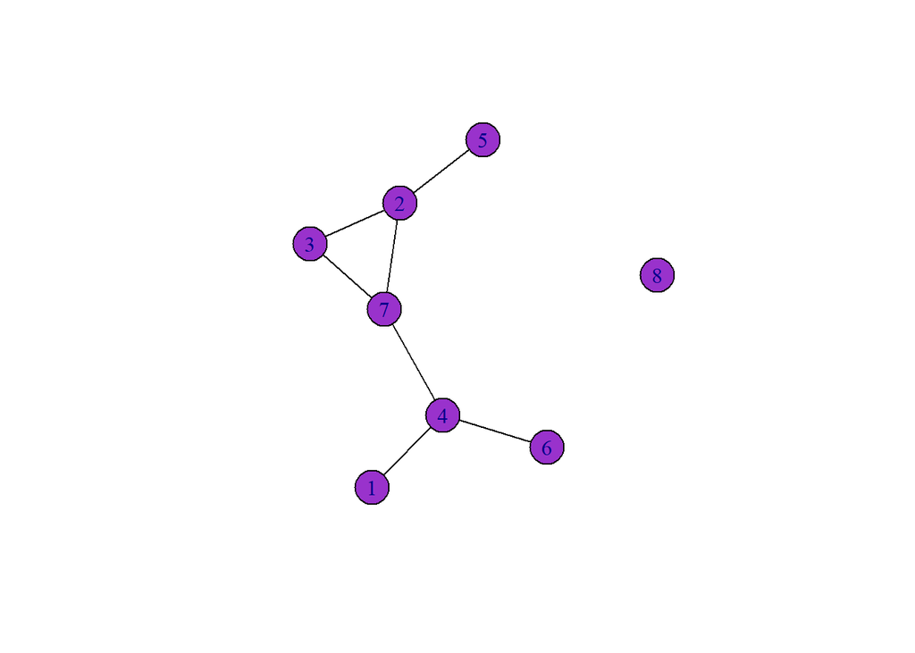

```r
set.seed(22051996)
g <- sample_gnp(8, 0.3, directed = FALSE, loops = FALSE) #Crea un grafo aleatorio con 6 nodos, no dirigido y con loops
plot(g,
     vertex.color="darkorchid",  # color de los nodos
     vertex.size=20,             # tamaño de los nodos
     edge.color="black")         # color de las aristas
```

```r
#Calculamos los grados de los nodos en g y ordenamos de mayor a menor.

degree(g) %>% sort(decreasing=TRUE)
```

```
## [1] 3 3 3 2 1 1 1 0
```

Los nodos 2, 4 y 7 tienen un valor de **grado del nodo** igual a 3; El nodo 3 tiene un **deg(v)= 2**; el resto dentro de esa componente con más nodos tiene un **deg(V)= 1**. El nodo restante en la otra componente tiene **deg(v)= 0**. Aunque en este caso no existe ningún loop, cabe mencionar que cuando existe un loop este por convención contribuye con 2 en lugar de 1 al valor del grado del nodo. Además a deg(v)= 0 se define como un **nodo aislado** y deg(v)=1 se define como un **nodo terminal**

La **secuencia de grado** de un Grafo consiste en los grados escritos en orden ascendente, con repeticiones cuando es necesario, como se muestra a continuación:

```r
degree(g) %>% sort(decreasing=FALSE)
```

```
## [1] 0 1 1 1 2 3 3 3
```

###Subgraphs Un **Subgrafo** de un grafo G es a su vez un grafo, en el cual cada uno de sus vertices pertenece a V(G) y cada uno de sus aristas pertenecen a E(G). En el ejemplo siguiente crearemos un nuevo grafo e, induciremos un subgrafo donde no se consideren los nodos 5 y 6.

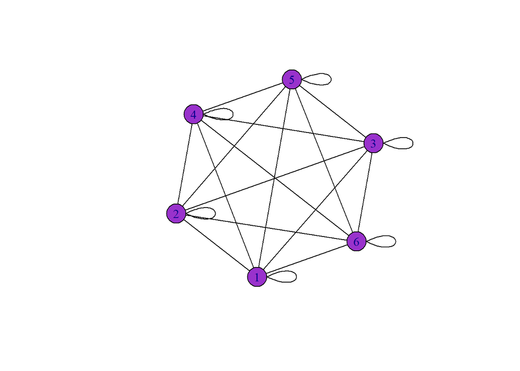

```r
set.seed(22051996)
g <- sample_gnp(6, 1, directed = FALSE, loops = TRUE) #Crea un grafo aleatorio con 6 nodos, no dirigido y con loops
plot(g,
     vertex.color="darkorchid",  # color de los nodos
     vertex.size=20,             # tamaño de los nodos
     edge.color="black")         # color de las aristas
```

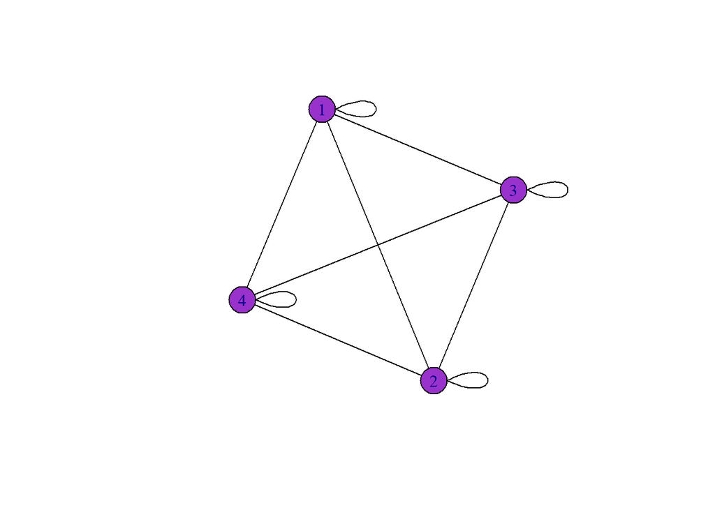

```r
g2 <- induced_subgraph(g, 1:4) #Induce un subgrafo del grafo en g que no contenga al nodo 5 y 6
plot(g2,
     vertex.color="darkorchid",  # color de los nodos
     vertex.size=20,             # tamaño de los nodos
     edge.color="black")         # color de las aristas
```

Podemos notar que en el nuevo subgrafo donde no se consideraron los nodos 5 y 6, también se descartan las aristas que unian estos nodos con los demás. Podríamos denotar a este subgrafo como **G-S** donde S es un set de vertices. **G-e** se refiere a un subgrafo donde no se considera un vertice del grafo original, esto se ejemplifica a continuación:

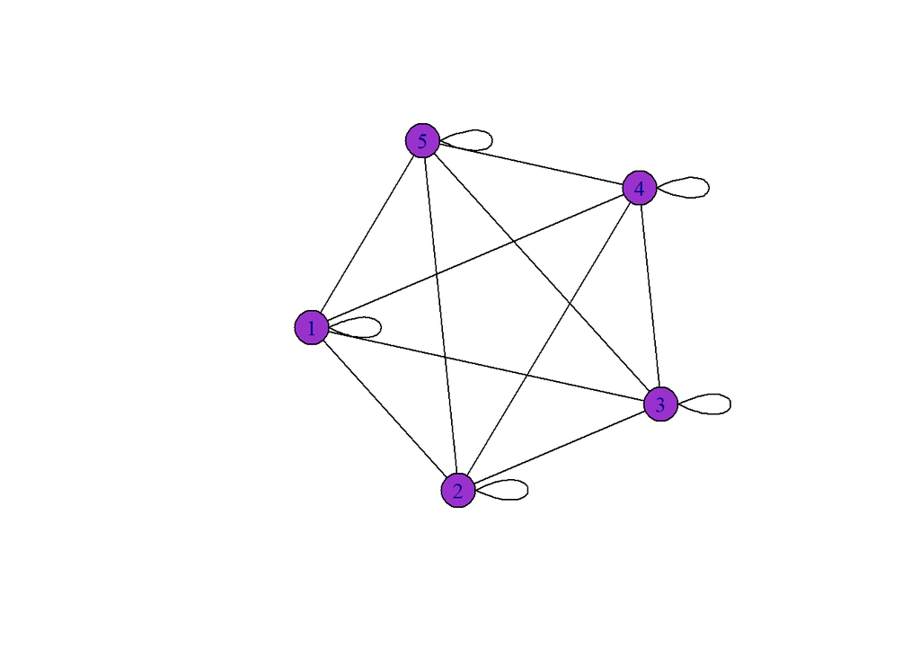

```r
g3 <- induced_subgraph(g, 1:5) #Induce un subgrafo del grafo en g que no contenga al nodo 6
plot(g3,
     vertex.color="darkorchid",  # color de los nodos
     vertex.size=20,             # tamaño de los nodos
     edge.color="black")         # color de las aristas
```

###Tipos de Grafos Revisaremos algunos tipos de grafos y aprovecharemos para revisar como podemos representar un grafo a traves de una *matriz de adyancencia*

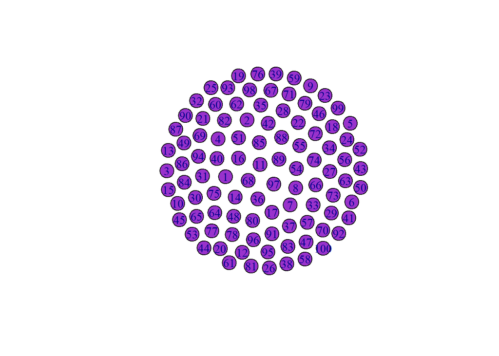

```r
g = make_empty_graph(100) #Creación de un grafo nulo
plot(g,
     vertex.color = "darkorchid")
```

```r
adj_m = g[] #Matriz de adyacencia
adj_m
```

[output not shown]

[output cut: 289 more lines]

En el ejemplo anterior se creo un *grafo nulo (Nn)*, como podemos observar este no contiene por definición aristas. Asi, al obtener la matriz de adyacencia, todos sus elementos se muestran vacios.

A continuación, crearemos un grafo en el que todos los nodos estan conectados con todos los otros nodos. En otras palabras cada par de nodos distintos son adyacentes. Este recibe el nombre de *grafo completo (Kn)*

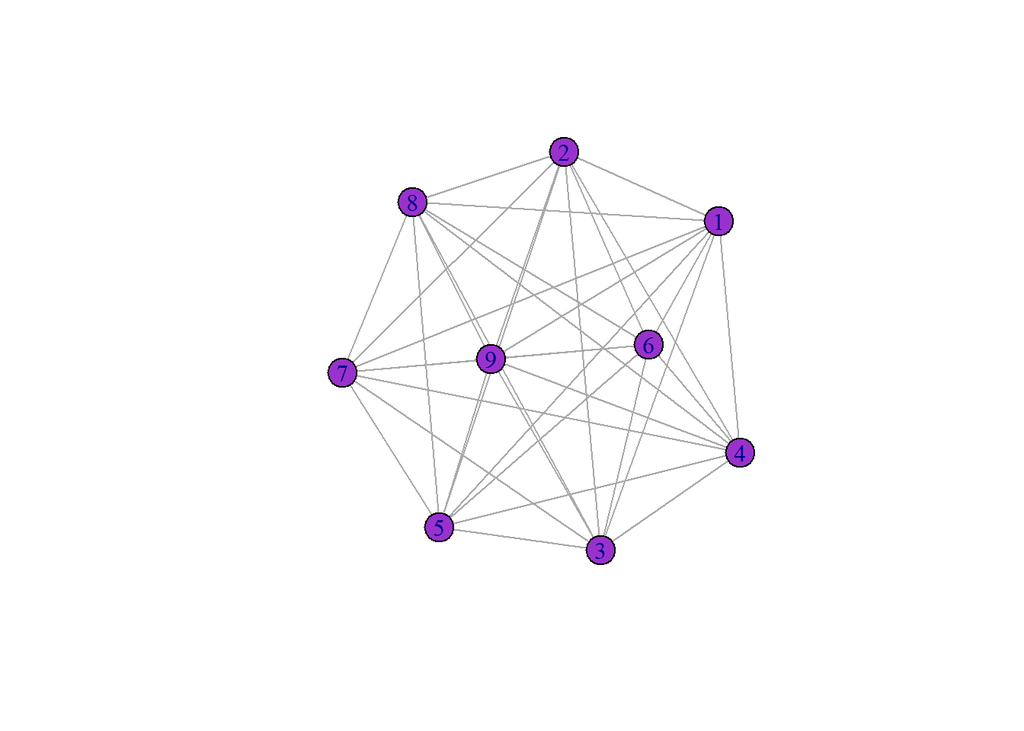

```r
g = make_full_graph(9)
plot(g,
     vertex.color = "darkorchid")
```

```r
adj_m = g[] #Matriz de adyacencia
adj_m
```

```
## 9 x 9 sparse Matrix of class "dgCMatrix"
##
##  [1,] . 1 1 1 1 1 1 1 1
##  [2,] 1 . 1 1 1 1 1 1 1
##  [3,] 1 1 . 1 1 1 1 1 1
##  [4,] 1 1 1 . 1 1 1 1 1
##  [5,] 1 1 1 1 . 1 1 1 1
##  [6,] 1 1 1 1 1 . 1 1 1
##  [7,] 1 1 1 1 1 1 . 1 1
##  [8,] 1 1 1 1 1 1 1 . 1
##  [9,] 1 1 1 1 1 1 1 1 .
```

Los grafos regulares son Un grafo en el cual cada uno de sus nodos tiene el mismo grado. Un ejemplo de grafo regular es quel de grado 2 *(2-regular)* que es un *Grafo de ciclo (Cn)*

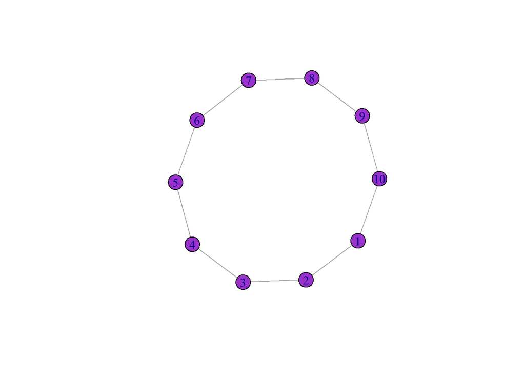

```r
r = make_ring(10) #Crea un grafo de ciclo con 10 nodos
plot(r,
     vertex.color = "darkorchid")
```